# HW 1 - Curve fitting to cytotoxicity data

Computational Toxicology

Lizbeth Gomez & Nastasia Gernat

2020-02-10

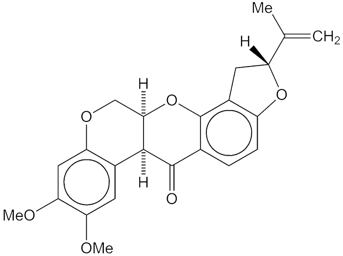

# Introduction:

Rotenone is a pesticide that can be found naturally in the Fabaceae family of legumes and other [plants](https://www.acs.org/content/acs/en/molecule-of-the-week/archive/r/rotenone.html) It’s use as a pesticide has since diminished as it has been found to interrupts the electron transport chain complex I and leads to mitochondrial dysfunction [dysfunction](https://www.sciencedirect.com/topics/neuroscience/rotenone) Exposure can cause muscle tremors, vomiting, tachycardia and hypotension. Chronic exposure to Rotenone correlates with Parkinson disease like symptoms in humans and to the degeneration of nigral dopaminergic [neurons](https://www.nature.com/articles/srep45465)

# Methods:

For this assignment a cytotoxicity assay was run with 10 exposure concentrations ranging from 0-5 μM of Rotenone. For each concentration there were six replicates run, which allowed us to look at the variability in cell death across the replications. Since the replicates had different cell counts, the percent death of each trial was averaged and then adjusted by replication; to do this, we divided the average cell count in each concentration by the cell number in non-treated conditions within replications.

# Calculations

## Coefficient of Variance:

We calculated the coefficients of variance (CV)of the mean percent death of the six replicates to analyze the variation of responses across replicates ( Shown in Table 1 below) using the formula:
$$CV=\frac{StandDev}{mean} * 100$$

## Four parameter log-logistic:

Four parameter log-logistic regression was run to fit a dose-response curve using the “drm” function within the “drc” package. The predictor variable was concentration and the outcome variable was mean percent cell death drom the control using the formula:
$$y=d +\frac{a-d}{1+ \frac{x}{c}^b}$$
Where:
a = the minimum value that can be obtained (i.e. what happens at 0 dose)

d = the maximum value that can be obtained (i.e. what happens at infinite dose)

c = the point of inflection (i.e. the point on the S shaped curve halfway between a and d)

b = Hill’s slope of the curve (i.e. this is related to the steepness of the curve at point c)  
[MyAssays](https://www.myassays.com/four-parameter-logistic-regression.html)

# Data Summary

```r
cyto_death = read_xlsx("data/cytotox_data.xlsx") %>%
  clean_names()

summary(cyto_death) %>%
  knitr::kable()
```

|  | concentration | rep_1 | rep_2 | rep_3 | rep_4 | rep_5 | rep_6 | avg_cell_death | from_ctr |
| --- | --- | --- | --- | --- | --- | --- | --- | --- | --- |
|  | Min. :0.0000 | Min. : 1.457 | Min. : 4.959 | Min. : 6.819 | Min. : 4.182 | Min. : 2.779 | Min. : 2.729 | Min. : 6.204 | Min. : 75.49 |
|  | 1st Qu.:0.0200 | 1st Qu.: 6.322 | 1st Qu.: 9.437 | 1st Qu.:16.693 | 1st Qu.: 6.522 | 1st Qu.:12.731 | 1st Qu.: 8.121 | 1st Qu.: 8.733 | 1st Qu.:106.26 |
|  | Median :0.1750 | Median :22.739 | Median :24.584 | Median :26.319 | Median :26.014 | Median :21.094 | Median :17.799 | Median :24.481 | Median :297.88 |
|  | Mean :0.9411 | Mean :17.850 | Mean :21.174 | Mean :22.690 | Mean :20.353 | Mean :20.273 | Mean :19.731 | Mean :20.345 | Mean :247.55 |
|  | 3rd Qu.:0.8750 | 3rd Qu.:25.049 | 3rd Qu.:30.043 | 3rd Qu.:28.091 | 3rd Qu.:29.160 | 3rd Qu.:28.153 | 3rd Qu.:27.656 | 3rd Qu.:28.268 | 3rd Qu.:343.95 |
|  | Max. :5.0000 | Max. :32.960 | Max. :39.766 | Max. :35.285 | Max. :40.276 | Max. :38.021 | Max. :44.000 | Max. :34.972 | Max. :425.52 |

# Cell death per replication

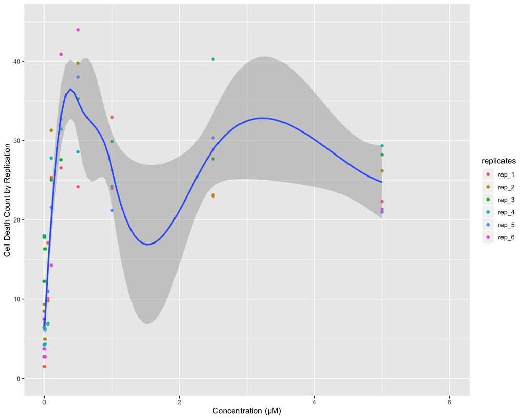

Cell death per replication.

```r
cyto_death_plot <- cyto_tidy_death %>%
  ggplot(aes(x = concentration, y = rep)) +
  ylim(0, 45) + xlim(0,6) +
  geom_point(aes(color = replicates)) +
  geom_smooth(method= "auto", se= TRUE) +
  xlab ("Concentration (μM)")+ ylab ("Cell Death Count by Replication")
cyto_death_plot
```

# Absolute percent cell death per concentration by replication

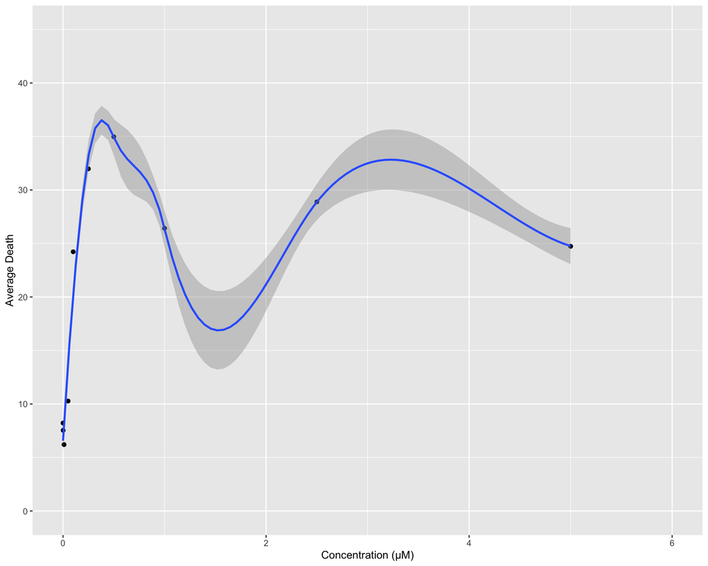

```r
cyto_death_plot_2 <- cyto_tidy_death %>%
  ggplot(aes(x = concentration, y = avg_cell_death)) +
  ylim(0, 45) + xlim(0,6) +
  geom_point() +
  geom_smooth(method= "auto", se= TRUE) +
  xlab ("Concentration (μM)")+ ylab ("Average Death")
cyto_death_plot_2
```

# Calculation of percent death from control

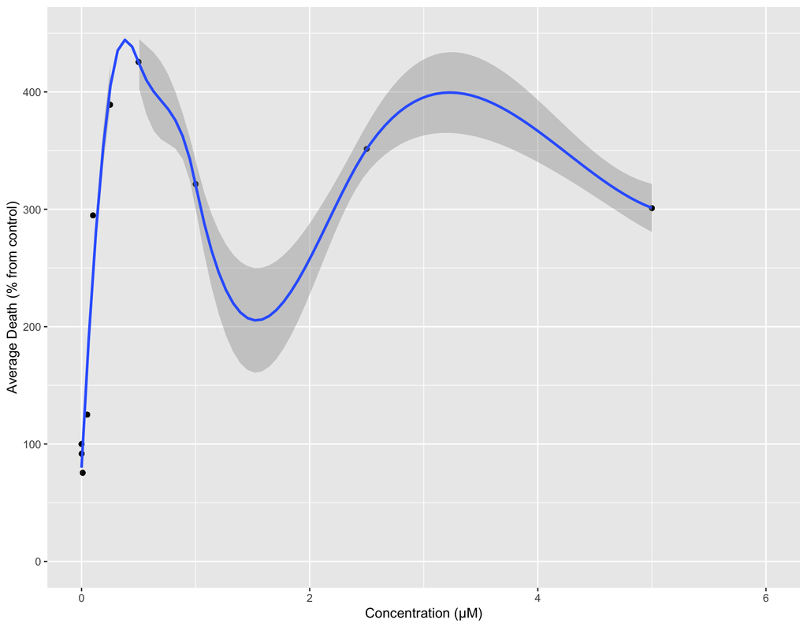

Percent death from control.

```r
cyto_death_plot_3 <- cyto_tidy_death %>%
  ggplot(aes(x = concentration, y = from_ctr)) +
  ylim(0, 450) + xlim(0,6) +
  geom_point() +
  geom_smooth(method= "auto", se= TRUE) +
  xlab ("Concentration (μM)")+ ylab ("Average Death (% from control)")
cyto_death_plot_3
```

# Results:

## Coefficient of variance

```r
cv_mean <- cyto_tidy_death %>%
 group_by(concentration)%>%
  summarise(mean = mean(rep),
            cv = cv(rep)) %>%
 knitr::kable()
  cv_mean
```

| concentration | mean | cv |
| --- | --- | --- |
| 0.000 | 8.218574 | 72.75949 |
| 0.001 | 7.537044 | 77.25855 |
| 0.010 | 6.204400 | 82.65797 |
| 0.050 | 10.275707 | 36.46630 |
| 0.100 | 24.226595 | 24.12076 |
| 0.250 | 31.977673 | 15.89939 |
| 0.500 | 34.971719 | 21.06594 |
| 1.000 | 26.418933 | 16.30543 |
| 2.500 | 28.884271 | 21.96060 |
| 5.000 | 24.735796 | 14.80658 |

# Four parameter log-logistic:

```r
summary(regress_cyto)
```

```
##
## Model fitted: Log-logistic (ED50 as parameter) (4 parms)
##
## Parameter estimates:
##
##                           Estimate Std. Error t-value   p-value
## Slope:(Intercept)       -4.5811715  0.7947123 -5.7646 3.660e-07 ***
## Lower Limit:(Intercept)  7.3587678  0.6522872 11.2815 4.638e-16 ***
## Upper Limit:(Intercept) 29.3922745  0.5076047 57.9039 < 2.2e-16 ***
## AC50:(Intercept)         0.0764826  0.0049467 15.4612 < 2.2e-16 ***
## ---
## Signif. codes:  0 '***' 0.001 '**' 0.01 '*' 0.05 '.' 0.1 ' ' 1
##
## Residual standard error:
##
##  2.764221 (56 degrees of freedom)
```

# 95% Confidence intervals for LD50

```r
ED(regress_cyto, 50, interval = "delta")%>%
 knitr::kable()
```

```
##
## Estimated effective doses
##
##         Estimate Std. Error     Lower     Upper
## e:1:50 0.0764826  0.0049467 0.0665731 0.0863921
```

|  | Estimate | Std. Error | Lower | Upper |
| --- | --- | --- | --- | --- |
| e:1:50 | 0.0764826 | 0.0049467 | 0.0665731 | 0.0863921 |

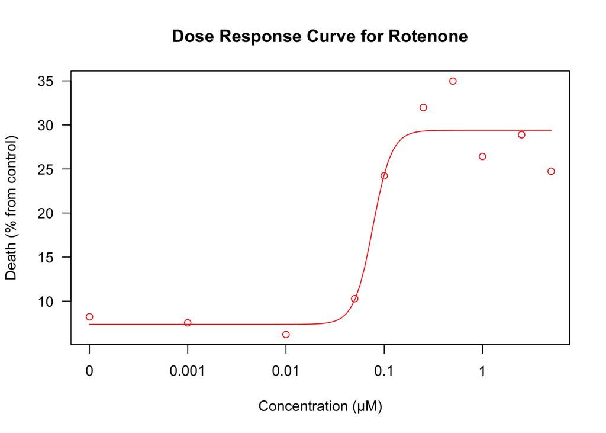

```r
plot(regress_cyto, xlab = "Concentration (μM)", ylab = "Death (% from control)", col = "red", main = "Dose Response Curve for Rotenone")
```